# swirl

*やりましたね。*

```
| The help page for plot() highlights the different arguments that the function can take. The two
| most important are x and y, the variables that will be plotted. For the next set of questions,
| include the argument names in your answers. That is, do not type plot(cars$speed, cars$dist),
| although that will work. Instead, use plot(x = cars$speed, y = cars$dist).

...
```

*plot() の Help ページには、関数がとることのできる引数についての説明を中心にしています。最も重要なのは、x と y で、プロットのための変数です。このあとのいくつかの練習問題では、引数名も一緒に加えてください。すなわち、plot(cars$speed, cars$dist) とするのではなく、plot(x = cars$speed, y = cars$dist) と引数名も加えてください。*

```
| Use plot() command to show speed on the x-axis and dist on the y-axis from the cars data frame.
| Use the form of the plot command in which vectors are explicitly passed in as arguments for x
| and y.
```

*plot() 関数を使い、cars データフレームを用い、x 軸に speed、y 軸に dist をとってください。plot 関数に x や y の引数とするベクトルを明示的に渡してください。*

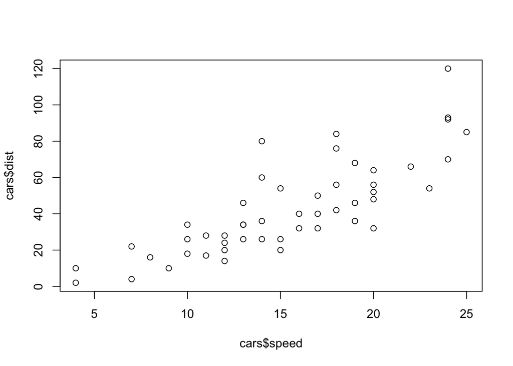

```
| You are doing so well!
```

```r
plot(x = cars$speed, y = cars$dist)
```

*とてもうまくいっていますよ。*

```
| Note that this produces a slightly different answer than plot(cars). In this case, R is not sure
| what you want to use as the labels on the axes, so it just uses the arguments which you pass in,
| data frame name and dollar signs included.

...
```

*これによって、plot(cars) とは少し異なるグラフが生じます。この場合は、R は、各軸のラベルとして何を使いたいのかはっきりしないので、引数として、わたしたものを、データフレームの名前とドル記号を使って表示します。*

```
| Note that there are other ways to call the plot command, i.e., using the "formula" interface.
| For example, we get a similar plot to the above with plot(dist ~ speed, cars). However, we will
| wait till later in the lesson before using the formula interface.

...
```

*他にも、plot を使う方法として、“formula”（式）を使う方法があります。たとえば、同様のプロットは、plot(dist ~ speed, cars) とでも得ることができます。しかし、この方法は、式で指定する方法を学ぶときまで保留することにします。*

```
| Use plot() command to show dist on the x-axis and speed on the y-axis from the cars data frame.
| This is the opposite of what we did above.
```

*x 軸に、dist、y 軸に speed を cars のデータフレームをつかって、plot() でグラフを表示してください。これは、上での方法の逆になっています。*

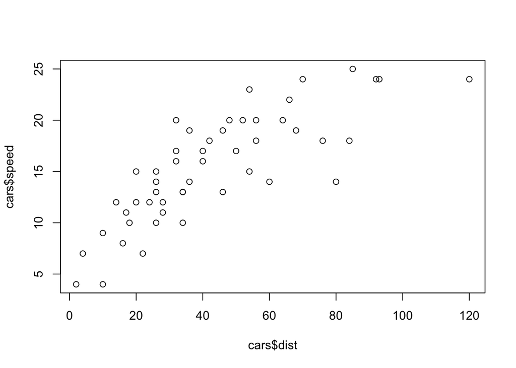

```
| You are doing so well!
```

```r
plot(x = cars$dist, y = cars$speed)
```

*とてもうまくいっていますよ。*

```
| It probably makes more sense for speed to go on the x-axis since stopping distance is a function
| of speed more than the other way around. So, for the rest of the questions in this portion of
| the lesson, always assign the arguments accordingly.

...
```

*speed を x 軸にとる方が、おそらくより自然でしょう。制動距離は、スピードによって変化するもので、その逆ではありませんから。そこで、残りの問題においては、最初にとった、引数のようにしましょう。*

```
| In fact, you can assume that the answers to the next few questions are all of the form plot(x =
| cars$speed, y = cars$dist, ...) but with various arguments used in place of the ...
```

*実際、次のいくつかの練習問題においては、plot(x = cars$speed, y = cars$dist, …) とし、… にいろいろな引数を使ってみましょう。*

```
| Recreate the plot with the label of the x-axis set to "Speed".
```

*もう一度、プロットを、x 軸に、“Speed” とラベルをつけて、作ってください。*

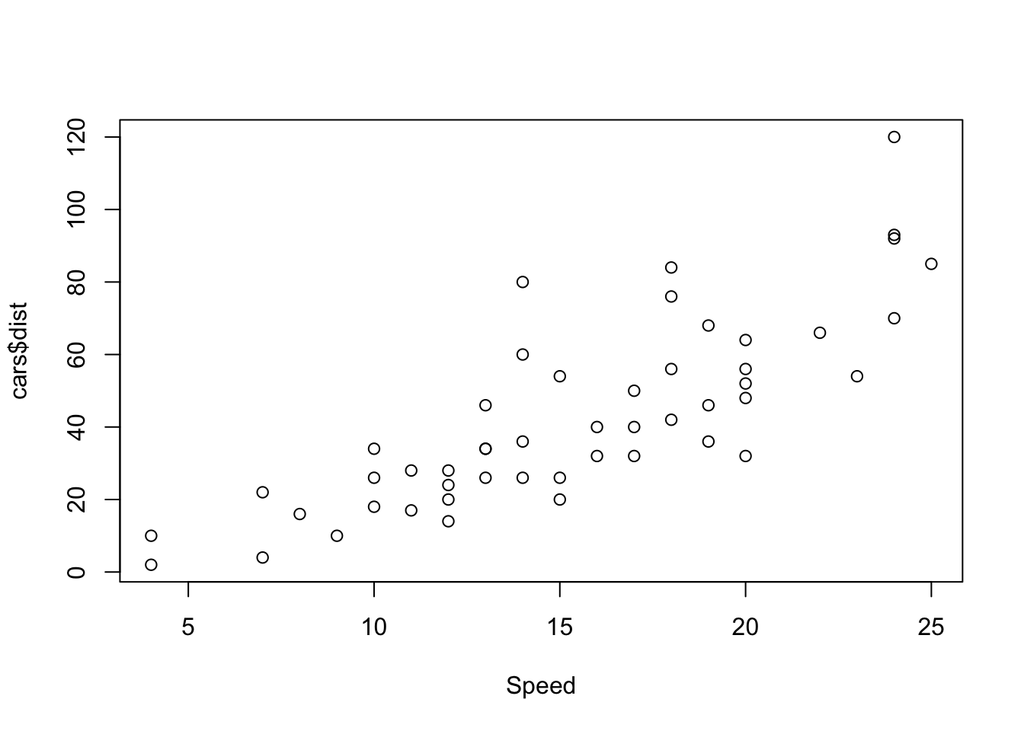

```
| Keep up the great work!
```

```r
plot(x = cars$speed, y = cars$dist, xlab = "Speed")
```

*その調子です。*

```
| Recreate the plot with the label of the y-axis set to "Stopping Distance".
```

*さらに、もう一度プロットを、y 軸に、“Stopping Distance” とラベルをつけて、作ってください。*

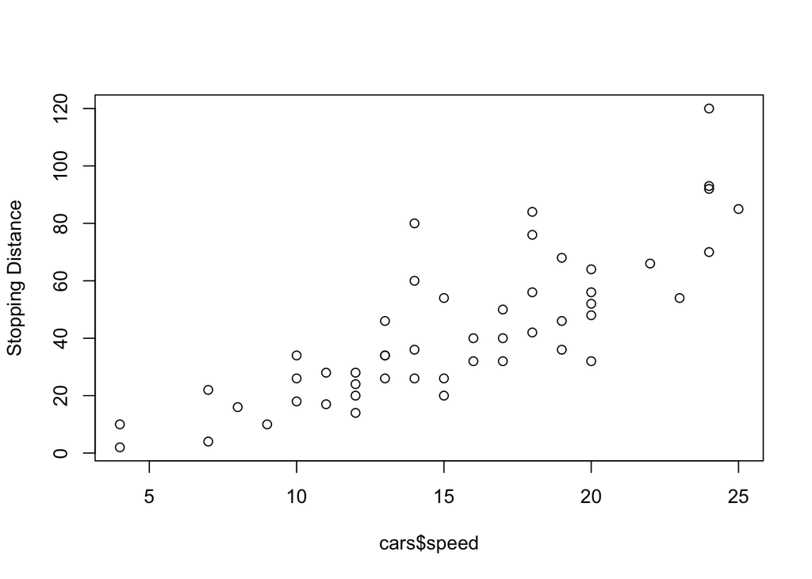

```
| You got it!
```

```r
plot(x = cars$speed, y = cars$dist, ylab = "Stopping Distance")
```

*その通りです。*

```
| Recreate the plot with "Speed" and "Stopping Distance" as axis labels.
```

*今度は、それぞれの軸のラベルとして、“Speed” と “Stopping Distance” を付けてプロットしてください。*

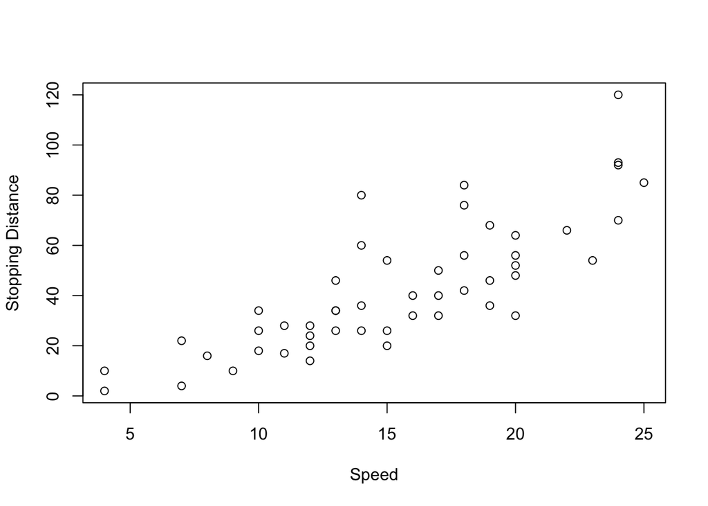

```
| Excellent work!
```

```r
plot(x = cars$speed, y = cars$dist, xlab = "Speed", ylab = "Stopping Distance")
```

*素晴らしい。*

```
| The reason that plots(cars) worked at the beginning of the lesson was that R was smart enough to
| know that the first element (i.e., the first column) in cars should be assigned to the x
| argument and the second element to the y argument. To save on typing, the next set of answers
| will all be of the form, plot(cars, ...) with various arguments added.

...
```

*最初に学んだように、plots(cars) によって、R は、賢くも、cars の第一成分（すなわち、第一列）を 引数 x とし、第二成分 を 引数 y にとりました。入力を省略するため、次のいくつかの解答は、plot(cars, …) として、いろいろな引数を付け加えてください。*

```
| For each question, we will only want one additional argument at a time. Of course, you can pass
| in more than one argument when doing a real project.

...
```

*それぞれの練習問題では、引数は一つだけ、加えるものとします。実際には、むろん、同時に、いくつもの引数を加えることができます。*

```
| Plot cars with a main title of "My Plot". Note that the argument for the main title is "main"
| not "title".
```

*主タイトルとして “My Plot” を付け加えてください。主タイトル（main title）の引数は、“main” です。*

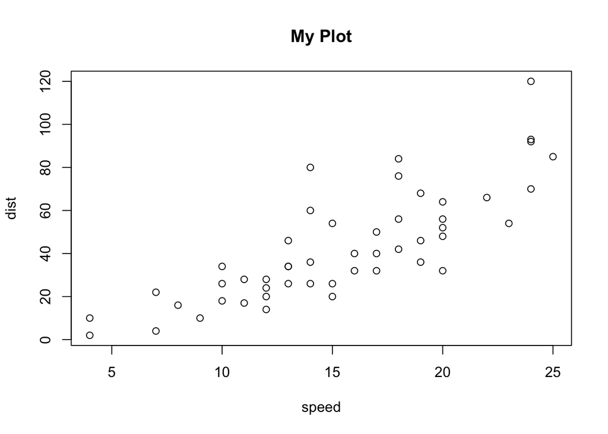

```
| You're the best!
```

```r
plot(cars, main = "My Plot")
```

*最高です。*

```
| Plot cars with a sub title of "My Plot Subtitle".
```

*副タイトルを、“My Plot Subtitle” として、cars をプロットしてください。*

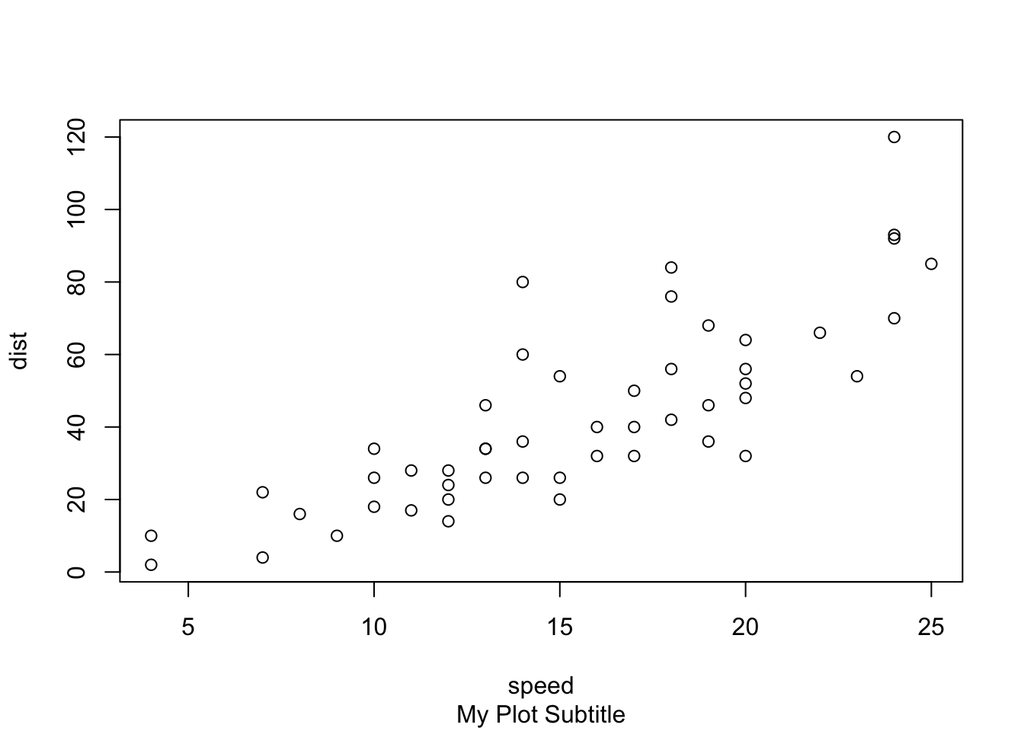

```
| You got it!
```

```r
plot(cars, sub = "My Plot Subtitle")
```

*その通りです。*

```
| The plot help page (?plot) only covers a small number of the many arguments that can be passed
| in to plot() and to other graphical functions. To begin to explore the many other options, look
| at ?par. Let's look at some of the more commonly used ones. Continue using plot(cars, ...) as
| the base answer to these questions.

...
```

*plot の Help (?plot) は、plot() 関数や、他のグラフィック関数のたくさんの引数のほんの一部だけを表示しています。?par とすると、他のオプションについて、調べることができます。良く利用するいくつかの引数について、見てみましょう。今後も、plot(cars, …) を使ってください。*

```
| Plot cars so that the plotted points are colored red. (Use col = 2 to achieve this effect.)
```

*色の赤を使って、cars をプロットしてください。（col = 2 とします。）*

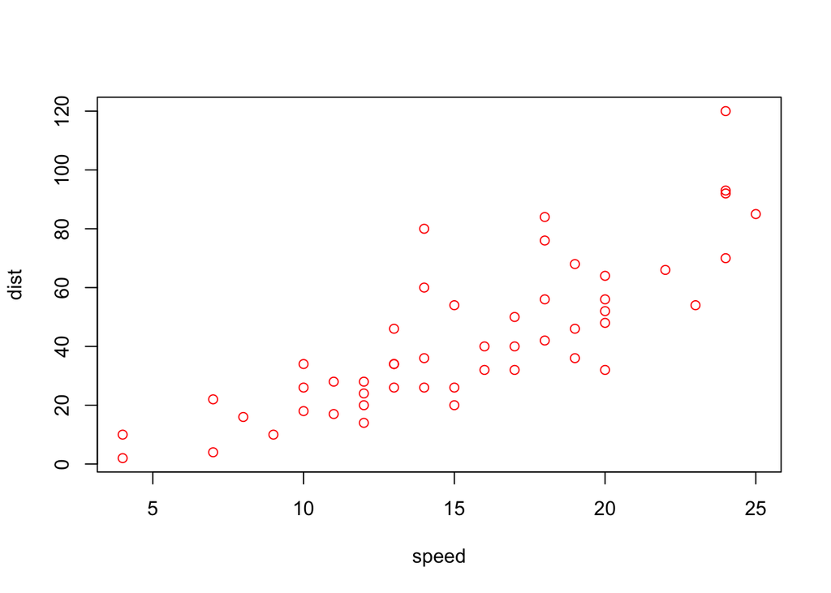

```
| You are really on a roll!
```

```r
plot(cars, col = 2)
```

*どんどん学んでいますね。*

```
| Plot cars while limiting the x-axis to 10 through 15.  (Use xlim = c(10, 15) to achieve this
| effect.)
```

*x 軸を 10 から 15 に制限して、cars をプロットしてください。（xlim = c(10, 15) とします。）*

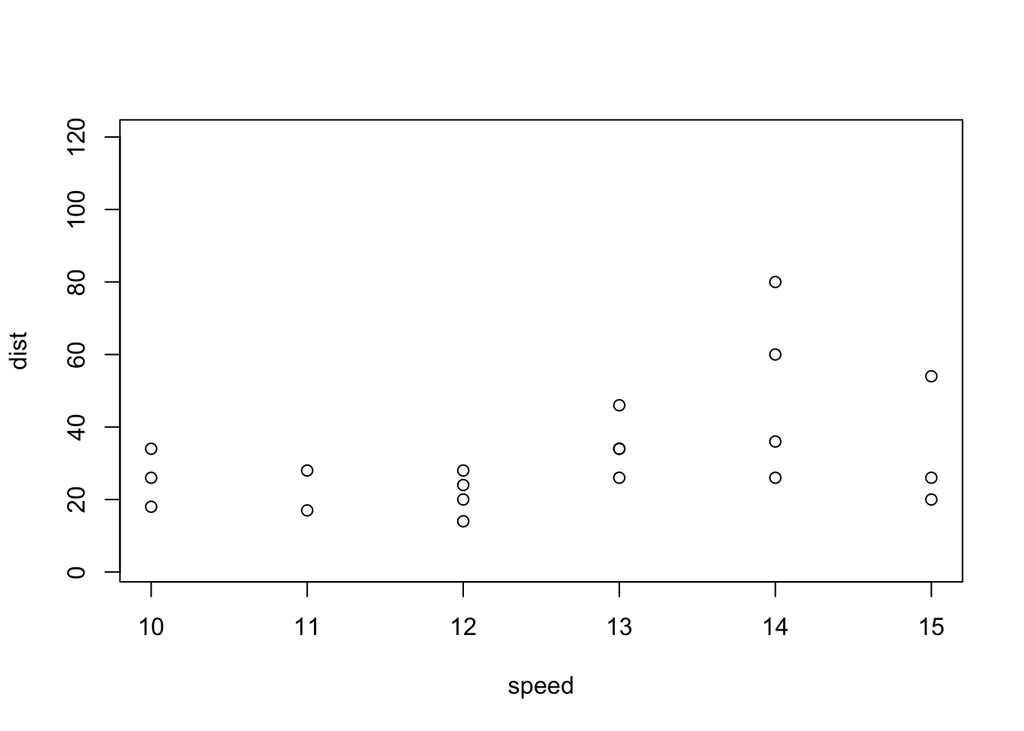

```
| Excellent work!
```

```r
plot(cars, xlim = c(10, 15))
```

*素晴らしい。*

```
| You can also change the shape of the symbols in the plot. The help page for points (?points)
| provides the details.

...
```

*plot する記号の形を変えることもできます。?points とすることで、Help を見ることができます。*

```
| Plot cars using triangles.  (Use pch = 2 to achieve this effect.)
```

*三角形を使って、cars をプロットしてください。（pch = 2 とします。）*

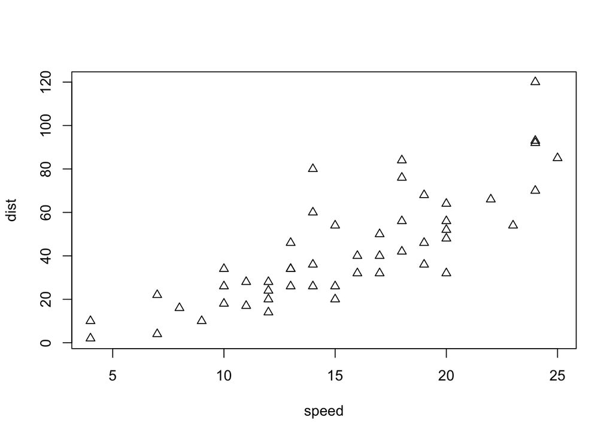

```
| You nailed it! Good job!
```

```r
plot(cars, pch = 2)
```

*見事です。*

```
| Arguments like "col" and "pch" may not seem very intuitive. And that is because they aren't! So,
| many/most people use more modern packages, like ggplot2, for creating their graphics in R.

...
```

*“col” や “pch” という引数は、あまり直観的にはみえないかもしれません。たしかに、そうです。そこで、多くの、または、ほとんどの人は、より現代的なパッケージである、ggplot2 を使って、R のグラフを作成しています。*

```
| It is, however, useful to have an introduction to base graphics because many of the idioms in
| lattice and ggplot2 are modeled on them.

...
```

*しかし、ベースのグラフィックを少し学んでおくことは、多くのことばが、lattice や、ggplot2 でも使われるので、有効です。*

```
| Let's now look at some other functions in base graphics that may be useful, starting with
| boxplots.

...
```

*ベースのグラフィック関数をいくつか見ていきましょう。boxplots からはじめます。*

```
| Load the mtcars data frame.
```

*mtcars データフレームを読み込んでください。*

```r
data(mtcars)
```

```
| You are amazing!
```

*驚きです。*

```
| Anytime that you load up a new data frame, you should explore it before using it. In the middle
| of a swirl lesson, just type play(). This temporarily suspends the lesson (without losing the
| work you have already done) and allows you to issue commands like dim(mtcars) and head(mtcars).
| Once you are done examining the data, just type nxt() and the lesson will pick up where it left
| off.

...
```

*新たにデータフレームを読み込んだら、使い始める前に、まずはどのようなものかを調べてみるべきです。swirl の課の途中では、play() と入力します。すると、これまでの部分は、失うこと亡く、一時的に課が中断され、dim(mtcars) とか、head(mtcars) と試すことができます。データを調べたら、nxt() と入力することで、中断したところから、はじめることができます。*

```
| Look up the help page for boxplot().
```

*boxplot() の Help を見てください。*

```
> ?boxplot

| All that hard work is paying off!
```